# *Ceratopteris* ddRADSeq data analysis

#### Analysis of raw reads & loci

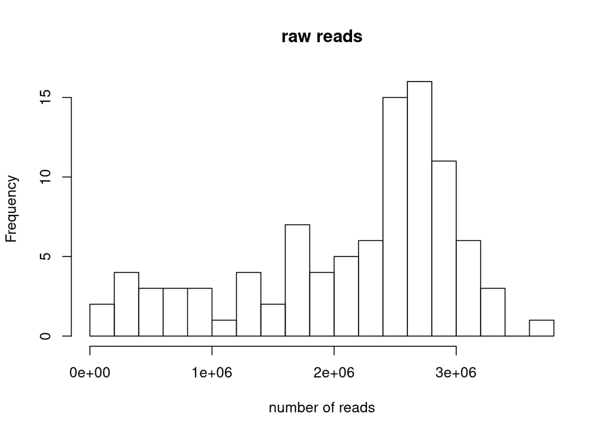

```r
d <- read.csv("./structure/reads.raw.txt", sep = ',', header = T)

hist(d[,2], main = "raw reads", xlab = "number of reads", breaks = 20)
```

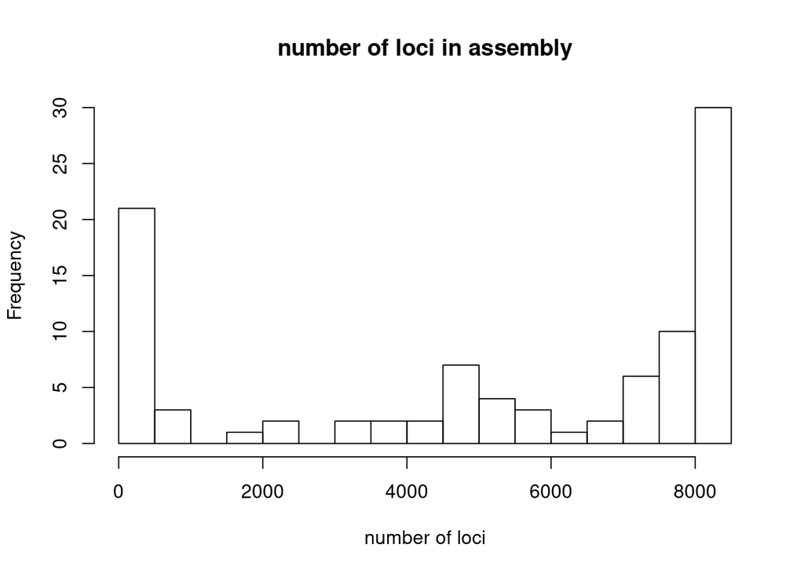

```r
hist(d[,3], main = "number of loci in assembly", xlab = "number of loci", breaks = 20)
```

## Population genomic analyses

#### gbs2ploidy

I converted the VCF file output by ipyrad to the gbs2ploidy format with this [Python script](https://github.com/carol-rowe666/vcf2hetAlleleDepth) written by Carol Rowe.

```r
library(gbs2ploidy)

# load sample names
ids <- read.csv("./HAD_ID.csv")

# load hetAlleleDepth table
# 56 samples with 2 alleles per samples = 112 columns
# 29625 SNPs / rows
het <- as.matrix(read.table("./hetAlleleDepth.txt", header = F))

# allele a for each ind
a <- seq(1, 100, 2)
# allele b for each ind
b <- seq(2, 100, 2)

# retrieve entire column (ind) for each allele (row)
cov1 <- het[,a]
cov2 <- het[,b]

# props = c(0.5, 0.66, 0.75) for last three proportions (our model)
# estprops: this functions uses Markov chain Monte Carlo to obtain Bayesian estimates of allelic proportions, which denote that proportion of heterozygous GBS SNPs with different allelic ratios.
propOut <- estprops(cov1 = cov1, cov2 = cov2, props = c(0.25, 0.33, 0.5, 0.66, 0.75), mcmc.nchain = 3, mcmc.steps = 10000, mcmc.burnin = 1000, mcmc.thin = 5)

# estprops returns a list with one component per individual. Components summarize the posterior distributions for allelic proportions.
# Rows correspond to different allelic proportions (as defined by ‘props’)
# Columns give the 2.5th, 25th, 50th, 75th, and 97.5th quantiles of the posterior distribution for each parameter
propOut[1:2]
# [[1]]
#            2.5%        25%        50%        75%     97.5%
# 0.25 0.02615469 0.04860941 0.06164483 0.07515569 0.1032398
# 0.33 0.02585112 0.05159050 0.06680296 0.08333787 0.1192802
# 0.5  0.13956566 0.18396947 0.20859096 0.23692481 0.2916249
# 0.66 0.14647331 0.21795926 0.25814796 0.29713085 0.3730970
# 0.75 0.31290242 0.36928452 0.39924378 0.43130653 0.4903253
#
# [[2]]
#              2.5%         25%        50%        75%      97.5%
# 0.25 0.1109331672 0.133872341 0.14586992 0.15856786 0.18260319
# 0.33 0.0005099962 0.005954433 0.01351898 0.02430852 0.05098758
# 0.5  0.1668016464 0.208449542 0.23031057 0.25328263 0.29781157
# 0.66 0.0894613061 0.153616076 0.19248894 0.23176188 0.30600852
# 0.75 0.3248250138 0.382064623 0.41320705 0.44262781 0.49606739

################################
# barplots
dev.new()
#pdf("g2p.pdf")
par(mfrow = c(4, 3))
for(i in 1:50){
  barplot(propOut[[i]][3:5,3], ylim = c(0,1), axes = FALSE, xlab = "Allelic ratios", ylab = "Posterior proportions", xaxt = 'n')
  axis(1, at = c(0.7, 1.9, 3.1), labels = c("1:1", "2:1", "3:1"))
  axis(2)
  box()
  segments(c(0.7, 1.9, 3.1), propOut[[i]][3:5,1], c(0.7, 1.9, 3.1), propOut[[i]][3:5,5])
  title(main = paste("sample name =", ids[[1]][i]))
}
dev.off()
```

#### STRUCTURE

The population genetics analysis program STRUCTURE (v. 2.3.4) was used to identify populations within the genus. For each k value, we ran 50 replicates (NOTE: include params files in github).

We used the [Cluster Markov Packager Across K (CLUMMPAK)](http://clumpak.tau.ac.il/) to combine replicates within k values.

Visualization of STRUCTURE was done in R with a custom script.

```r
# load in ks from clummpack files
k2 <- read.csv("k2.txt", sep = '', header = F)
k2 <- k2[,-(1:5)]
k3 <- read.csv("k3.txt", sep = '', header = F)
k3 <- k3[,-(1:5)]
k4 <- read.csv("k4.txt", sep = '', header = F)
k4 <- k4[,-(1:5)]
k5 <- read.csv("k5.txt", sep = '', header = F)
k5 <- k5[,-(1:5)]
k6 <- read.csv("k6.txt", sep = '', header = F)
k6 <- k6[,-(1:5)]
k7 <- read.csv("k7.txt", sep = '', header = F)
k7 <- k7[,-(1:5)]

# names file includes individual ids, species names, and geographic locations
names <- read.csv("names.csv", sep = ',', header = F)

x <- as.data.frame(matrix(ncol = 23, nrow = 108))
x[,1:2] <- k2
x[,3:5] <- k3
x[,6:9] <- k4
x[,10:14] <- k5
x[,15:20] <- k6
#x[,21:27] <- k7
x[,21:23] <- names[,1:3]
x[,24] <- names[,6]

# order by species, then geography
x <- x[order(x[,24]),]

## find locations for each column, each species
## variables
# labels - species names
# xlabels - specimen labels
# ninds - number of individuals
# klist - list of x values

labels <- x[,23]
x_lables <- x[,21]
ninds <- 108
klist <- list(x[,1:2], x[,3:5], x[,6:9], x[,10:14], x[,15:20])

# each unique species names
sp.names <- as.character(unique(labels))

# locations of each column, found via barplot column locations
b <- as.data.frame(matrix(ncol = 1, nrow = ninds))
b[,1] <- barplot(t(klist[[1]][1]), beside = F, col = c('black', 'white'), cex.name = 1, cex.axis = 1.2, border = 1, space = 0.05, xaxt = 'n', yaxt = 'n', cex.lab = 1, cex.main = 2)

# find locations for labels in the barplot
my.mean <- tapply(X = b[,1], INDEX = labels, mean)
my.min <- tapply(X = b[,1], INDEX = labels, min)
my.max <- tapply(X = b[,1], INDEX = labels, max)

# data frame for plotting
d <- sp_labels(names = sp.names, min = my.min, mean = my.mean, max = my.max)

plot_chains_species(kqlist = klist, xlabel = x_labels)

#######################################################
# functions needed
######################################################

# plotting and labeling function

# create labels
sp_labels <- function(names, min, mean, max, ...){
    d <- as.data.frame(matrix(nrow = length(names), ncol = 4))
    colnames(d) <- c("names", "min", "mean", "max")
    for (j in 1:length(names)){
            d[j,1] <- names[j]
            d[j,3] <- min[[j]][1]
            d[j,2] <- mean[[j]][1]
            d[j,4] <- max[[j]][1]
    }
    return(d)
}

# plot chains
plot_chains_ids <- function(kqlist, xlabel){

    # define colors
    cols <- c('#A8FFFD','#B862D3', '#A39D9D','#FFFF00', '#69C261', '#FF59AC', '#26CDCD',  '#C1C6FF')

    par(mfrow = c(length(kqlist),1), mar = c(1,3,3,1) + 0.1, oma = c(15,0,0,0), mgp = c(1,1,0))
    chain <- seq(1, length(kqlist), 1)

    # plot ks
    for(i in 1:(length(kqlist)-1)){
        barplot(t(kqlist[[i]]), beside = F, col = cols, border = 1, space = 0.05, xaxt = 'n', yaxt = 'n', ylab = paste("k =", chain[i]+1, sep = ' '), cex.lab = 1.2, cex.main = 1.6)
        # y axis
        axis(2, at = c(0, 0.25, 0.5, 0.75, 1), cex.axis = 1, las = 2, pos = -0.2)

        # lines
        for (i in 1:length(d[,1])){
            lines(x = d[i,3:4] , y = rep(-0.09, 2), lwd = 2.5, col = "black", xpd = NA)
            #lines(x = d[i,3:4] , y = rep(1.1, 2), lwd = 2.5, col = "black", xpd = NA, )
        }
    }

    # plot last k with labels
    for(i in length(kqlist)){
        barplot(t(kqlist[[i]]), beside = F, col = cols, border = 1, space = 0.05, yaxt = 'n', ylab = paste("k =", chain[i]+1, sep = ' '), cex.lab = 1.1, cex.main = 1.6, names.arg = xlabel, las = 2)
        # y axis
        axis(2, at = c(0, 0.25, 0.5, 0.75, 1), cex.axis = 1, las = 2, pos = -0.2)

        # lines
        for (i in 1:length(d[,1])){
            lines(x = d[i,3:4] , y = rep(-0.09, 2), lwd = 2.5, col = "black", xpd = NA, )
        }
    }

}


plot_chains_species <- function(kqlist, xlabel){

    # define colors
    cols <- c('#A8FFFD','#B862D3', '#A39D9D','#FFFF00', '#69C261', '#FF59AC', '#26CDCD',  '#C1C6FF')
    #cols <- c('#000075', '#E6194B', '#AAFFC3', '#FFE119', '#F58231', '#3CB44B')

    par(mfrow = c(length(kqlist),1), mar = c(1,3,3,1) + 0.1, oma = c(15,0,0,0), mgp = c(1,1,0))
    chain <- seq(1, length(kqlist), 1)

    for(i in 1:length(kqlist)){
        barplot(t(kqlist[[i]]), beside = F, col = cols, border = 1, space = 0.05, xaxt = 'n', yaxt = 'n', ylab = paste("k =", chain[i]+1, sep = ' '), cex.lab = 1.2, cex.main = 1.6)
        # y axis
        axis(2, at = c(0, 0.25, 0.5, 0.75, 1), cex.axis = 1, las = 2, pos = -0.2)

        # lines
        for (i in 1:length(d[,1])){
            lines(x = d[i,3:4] , y = rep(-0.1, 2), lwd = 2.5, col = "black", xpd = NA)
        }
    }
    # labels
    text(cex = 1.3, x = (d[,2]-0.3), y = -0.7, labels = d[,1], xpd=NA, srt=50, font=3)
}

##############################
# saving pdfs
##############################

pdf('k2-6_hnn_ids.pdf', width = 10, height = 9)
plot_chains_ids(kqlist = klist, xlabel = x_labels)
dev.off()
```

#### Tetrad

ipyrad inferring quartet trees with [tetrad](https://nbviewer.jupyter.org/github/dereneaton/ipyrad/blob/master/tests/cookbook-quartet-species-tree.ipynb)

Command line, on a server

```bash
# start an interactive job
srun -t 24:00:00 -n 24 -N 1 -A usubio-kp -p usubio-kp --pty /bin/bash -l

# start ipcluster
ipcluster start --n=24 --daemonize
```

Python

```perl
import ipyrad.analysis as ipa
import ipyparallel as ipp
import toytree

ipyclient = ipp.Client()
print("connected to {} cores".format(len(ipyclient)))
# connected to 24 cores

tet = ipa.tetrad(
    name='nr',
    data="./og-nr.snps.hdf5",
    nboots=50,
)

tet = ipa.tetrad(
    name='nh',
    data="../nr_rev.snps.hdf5",
    nboots=50,
)

# loading seq array [57 taxa x 29849 bp]
# max unlinked SNPs per quartet (nloci): 8602

tet.run(ipyclient=ipyclient)
# host comput node: [24 cores] on kp382
# inferring 395010 induced quartet trees
# [####################] 100%  initial tree | 0:00:33 |
# [####################] 100%  boot 100     | 0:47:22 |
```

#### RAxML

```bash
raxml -s ../og-nr.phy -n og-nr.out -m GTRCAT -f a -x $RANDOM -N 1000 -p $RANDOM -T 24
```

Plotting

```r
library(ape)
library(phytools)
# https://github.com/willpearse/willeerd
library(willeerd)

# read in tree
t <- read.tree("cer.tree")

# root tree
t <- root(phy = t, outgroup = "AcAu", resolve.root = T)
plot(t, cex = 0.8)

# hack to remove tip labels in final plot
t$tip.label <- as.character(cnames$str_sp)
t$tip.label[32] <- "Acrostichum"
t$tip.label[1:31] <- ""
t$tip.label[33:51] <- ""

# plot tree with tip labels, node lables, to find clades
plotTree(t, ftype = 'i')
nodelabels(frame = "circ", bg = "white", cex = 0.8)

# plot tree with no tip labels, clade labels only
plotTree(t, ftype = 'i')
cladelabels(tree = t, text = c("pteridoides", "thalictroides 2", "gaudichaudii", "thalictroides 1", "cornuta", "cornuta"), node = c(83, 94, 88, 76, 82, 78), cex = 0.8, offset = 1.2, wing.length = 0)

t$tip.label <- rep("", 51)
t$tip.label[32] <- "Acrostichum"

# define subtrees
painted <- paintSubTree(tree = t, node = 83, "pteridoides", "0")
painted <- paintSubTree(painted, 94, state = "thalictroides 2")
painted <- paintSubTree(painted, 88, state = "gaudichaudii")
painted <- paintSubTree(painted, 76, state = "thalictroides 1")
painted <- paintSubTree(painted, 82, state = "cornuta")
painted <- paintSubTree(painted, 78, state = "cornuta")

# pteridoides, thal 2, gaudichaudii, thal 1, cornuta x2
cols <- c('#A39D9D', '#000000', '#f2f202', '#B862D3', '#a4f4f3','#69C261', '#69C261')
names(cols) <- c("pteridoides", "0", "thalictroides 2", "gaudichaudii", "thalictroides 1", "cornuta", "cornuta")

# plot painted tree with labels and node support
plotSimmap(painted, cols, lwd = 3)
cladelabels(tree = t, text = c("pteridoides", "thalictroides 2", "gaudichaudii", "thalictroides 1", "cornuta", "cornuta"), node = c(83, 94, 88, 76, 82, 78), cex = 1, offset = 1.2, wing.length = 0)
# edgelabels(t$edge.length, frame = 'none')

##########################################################
# raxml tree

plotTree(t, ftype = 'i')
cladelabels(tree = t, text = c("pteridoides", "thalictroides 2", "gaudichaudii", "thalictroides 1", "cornuta", "cornuta"), node = c(96, 55, 90, 62, 88, 53), cex = 0.8, offset = 1.2, wing.length = 0)

# define subtrees
painted <- paintSubTree(tree = t, node = 96, "pteridoides", "0")
painted <- paintSubTree(painted, 55, state = "thalictroides 2")
painted <- paintSubTree(painted, 90, state = "gaudichaudii")
painted <- paintSubTree(painted, 62, state = "thalictroides 1")
painted <- paintSubTree(painted, 88, state = "cornuta")
painted <- paintSubTree(painted, 53, state = "cornuta")

# pteridoides, thal 2, gaudichaudii, thal 1, cornutax2
cols <- c('#fff400', '#000000', '#fff400', '#A8FFFD', '#A39D9D', '#69C261', '#69C261')
names(cols) <- c("pteridoides", "0", "thalictroides 2", "gaudichaudii", "thalictroides 1", "cornuta", "cornuta")

# plot painted tree with labels
plotSimmap(painted, cols, lwd = 3)
cladelabels(tree = t, text = c("pteridoides", "thalictroides 2", "gaudichaudii", "thalictroides 1", "cornuta", "cornuta"), node = c(96, 55, 90, 62, 88, 53), cex = 0.8, offset = 1.2, wing.length = 0)

############################################################
# cophylo

# t = tetrad tree, r = raxml tree
t <- drop.tip(phy = t, tip = "AcAu")

n <- cophylo(r, t)

cols <- c('#A39D9D', '#000000', '#f2f202', '#B862D3', '#a4f4f3','#69C261', '#69C261')
##################################
## left side, raxml tree
# pteridoides
nodes <- getDescendants(n$trees[[1]], 51)
left <- rep("black", nrow(n$trees[[1]]$edge))
left[sapply(nodes, function(x, y) which(y==x), y = n$trees[[1]]$edge[,2])] <- '#A39D9D'

# fill in edges outside of pteridoides grade
nodes <- getDescendants(n$trees[[1]], 55)
left[sapply(nodes, function(x, y) which(y==x), y = n$trees[[1]]$edge[,2])] <- 'black'

# cornuta
nodes <- getDescendants(n$trees[[1]], 98)
left[sapply(nodes, function(x, y) which(y==x), y = n$trees[[1]]$edge[,2])] <- '#69C261'

nodes <- getDescendants(n$trees[[1]], 84)
left[sapply(nodes, function(x, y) which(y==x), y = n$trees[[1]]$edge[,2])] <- '#69C261'

# thalictroides 1
nodes <- getDescendants(n$trees[[1]], 58)
left[sapply(nodes, function(x, y) which(y==x), y = n$trees[[1]]$edge[,2])] <- '#a4f4f3'

# thalictroides 2
nodes <- getDescendants(n$trees[[1]], 92)
left[sapply(nodes, function(x, y) which(y==x), y = n$trees[[1]]$edge[,2])] <- '#f2f202'

# gaudichaudii
nodes <- getDescendants(n$trees[[1]], 86)
left[sapply(nodes, function(x, y) which(y==x), y = n$trees[[1]]$edge[,2])] <- '#B862D3'

#######################################
## right side, tetrad tree
right <- rep("black", nrow(n$trees[[2]]$edge))

# pteridoides
nodes <- getDescendants(n$trees[[2]], 95)
right[sapply(nodes, function(x, y) which(y==x), y = n$trees[[2]]$edge[,2])] <- '#A39D9D'

# cornuta
nodes <- getDescendants(n$trees[[2]], 94)
right[sapply(nodes, function(x, y) which(y==x), y = n$trees[[2]]$edge[,2])] <- '#69C261'

nodes <- getDescendants(n$trees[[2]], 79)
right[sapply(nodes, function(x, y) which(y==x), y = n$trees[[2]]$edge[,2])] <- '#69C261'

# thalictroides 1
nodes <- getDescendants(n$trees[[2]], 56)
right[sapply(nodes, function(x, y) which(y==x), y = n$trees[[2]]$edge[,2])] <- '#a4f4f3'

# thalictroides 2
nodes <- getDescendants(n$trees[[2]], 88)
right[sapply(nodes, function(x, y) which(y==x), y = n$trees[[2]]$edge[,2])] <- '#fff400'

# gaudichaudii
nodes <- getDescendants(n$trees[[2]], 82)
right[sapply(nodes, function(x, y) which(y==x), y = n$trees[[2]]$edge[,2])] <- '#B862D3'

# plotting
edge.col <- list(left = left, right = right)
plot(n, link.type = "curved", link.lty = "solid", fsize = 0.8, edge.col = edge.col, link.col = "grey", edge.width = 5)

legend(1.5, 250, legend = c("RAxML tree - right", "TETRAD tree - left"), pch = 19, cex = 2, bty= "n", text.font = 3)

################################################
# Robinson-Foulds distance

library(phangorn)

r <- read.tree("raxml_rooted.tre")
t <- read.tree("tetrad_rooted.tre")

RF.dist(r, t, rooted = T)
# 61
RF.dist(r, t, rooted = T, normalize = T)
# .06421053

#############################################################
# trying to sort one column by another with the same names in a different order
# m <- match(names[,1], c_names[,1])
# match_names <- match_names[order(m),]
```

#### Map

```r
library(fields)

# read in location data
p <- read.csv("cer_locations.csv", header = T, sep = ',')

# map
map('world', fill = T, col = 'white', border = 'white', bg = 'lightgrey')

# OW thalictroides, blue
points(p[c(18:31, 33:35),5], p[c(18:31, 33:35),4], col = "#000000", bg = "#A8FFFD", cex = 2, pch = 21)

# NW thalictroides, yellow
points(p[c(17, 32, 36:39),5], p[c(17, 32, 36:39), 4], col = "#000000", bg = "#FFFF00", cex = 2, pch = 21)

# cornuta, green
points(p[2:5,5], p[2:5,4], col = "#000000", bg = "#69C261", cex = 2, pch = 21)

# gaudichaudii, purple
points(p[6:7,5], p[6:7,4], col = "#000000", bg = "#B862D3", cex = 2, pch = 21)

# pteridoides, grey
points(p[8:13,5], p[8:13,4], col = "#000000", bg = "#A39D9D", cex = 2, pch = 21)

# richardii, pink
points(p[14:16,5], p[14:16,4], col = "#000000", bg = "#FF59AC", cex = 2, pch = 21)

#legend(-170, -2, legend = c("C. gaudichaudii", "C. cornuta", "C. pteridoides", "C. richardii", "C. thalictroides"), bg = "white", pch = 19, cex = 1.5, col = c("#B862D3", "#69C261", "#FFFF00", "#FF59AC", "#A8FFFD"), text.font = 3)

legend(-170, -2, legend = c("C. thalictroides 1", "C. thalictroides 2", "C. cornuta", "C. gaudichaudii", "C. pteridoides", "C. richardii"), bg = "white", pch = 19, cex = 1.5, col = c("#A8FFFD", "#FFFF00", "#69C261", "#B862D3", "#A39D9D", "#FF59AC"), text.font = 3)
```